# Explore House Sale Data

10/16/2016

## Outlines

- Background of data
- Insights explored from data
- Reference: https://www.kaggle.com/c/house-prices-advanced-regression-techniques/data.

## Background of Data

- The data set describes the sale of individual residential property in Ames, Iowa from 2006 to 2010.
- The data selected for this visualization project (8 attritubes, 1456 observations) includes Categorial data, Continuous data.
- "*The variables focus on the quality and quantity of many physical attributes of the property. Most of the variables are exactly the type of information that a typical home buyer would want to know about a potential property.*"[1]
- [1]"Ames, Iowa: Alternative to the Boston Housing Data as an End of Semester Regression Project", Dean De Cock, Truman State University

## Background of Data

- 8 attritubes selected, 1456 observations
- **Sale Price** (in $)
- **Year Built** : original construction date
- **Year Sold**
- **Month Sold**
- **House Style**: style of dwelling
- **House Location Zone**: identifies the general zoning classification of the sale.
- **Foundation**: type of foundation
- **Overall Quality** (from 1 to 10)

## Background of Data

```r
summary(house_data)
```

```
##     MSZoning      HouseStyle   OverallQual       YearBuilt     Foundation
##  C (all):  10   1Story :726   Min.   : 1.000   Min.   :1872   BrkTil:146
##  FV     :  65   2Story :441   1st Qu.: 5.000   1st Qu.:1954   CBlock:634
##  RH     :  16   1.5Fin :154   Median : 6.000   Median :1972   PConc :643
##  RL     :1147   SLvl   : 65   Mean   : 6.089   Mean   :1971   Slab  : 24
##  RM     : 218   SFoyer : 37   3rd Qu.: 7.000   3rd Qu.:2000   Stone :  6
##                 1.5Unf : 14   Max.   :10.000   Max.   :2010   Wood  :  3
##                 (Other): 19
##      MoSold           YrSold       SalePrice
##  Min.   : 1.000   Min.   :2006   Min.   : 34900
##  1st Qu.: 5.000   1st Qu.:2007   1st Qu.:129900
##  Median : 6.000   Median :2008   Median :163000
##  Mean   : 6.326   Mean   :2008   Mean   :180151
##  3rd Qu.: 8.000   3rd Qu.:2009   3rd Qu.:214000
##  Max.   :12.000   Max.   :2010   Max.   :625000
##
```

## Prices Trend with House Built Year

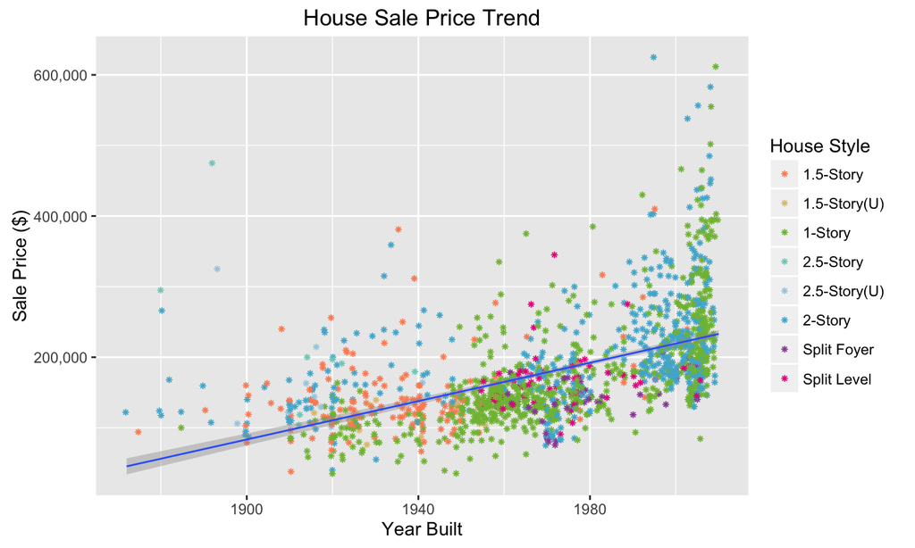

## House Prices: Popular House Styles

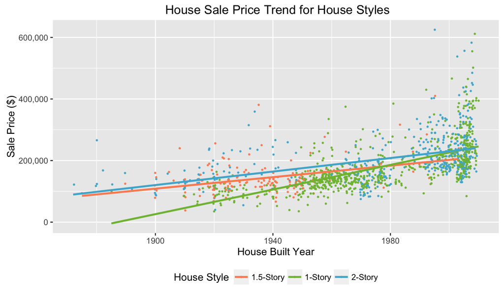

## House Prices: Discontinued … and Emerged House Styles

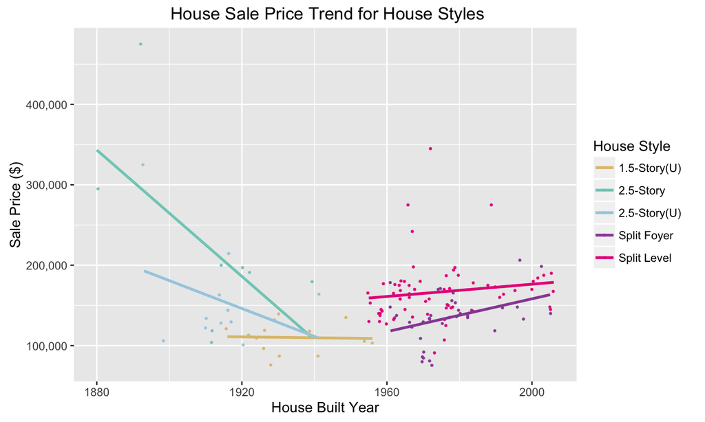

## House Prices Trends with Sold Years

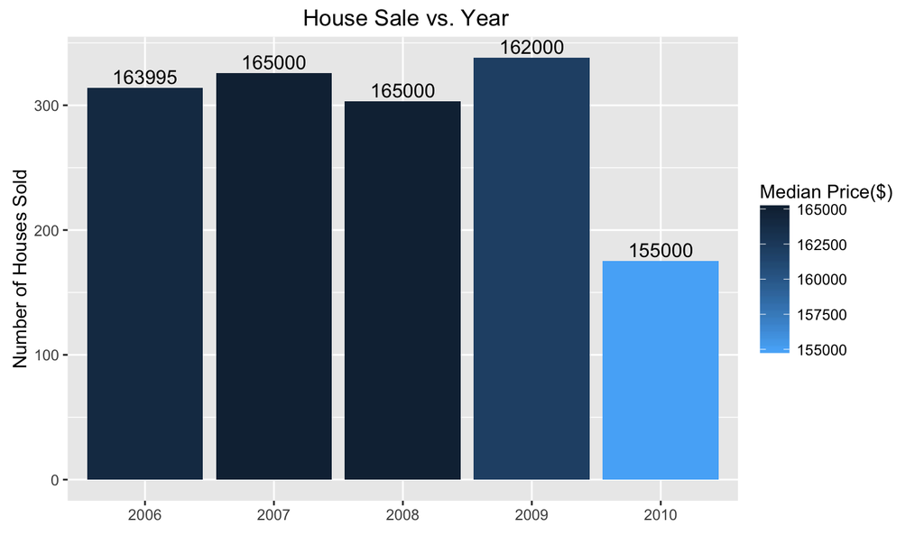

## Houses Price Trends with Sold Month

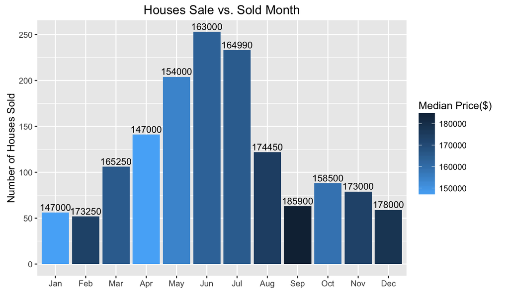

## House Prices with Different Zones

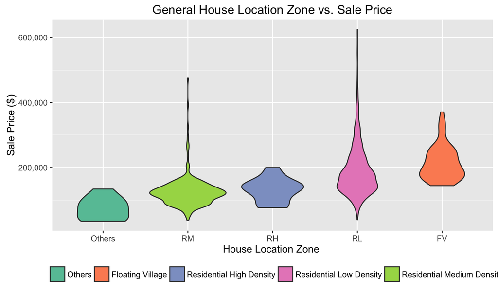

## Foundations Matters House Overall Quality

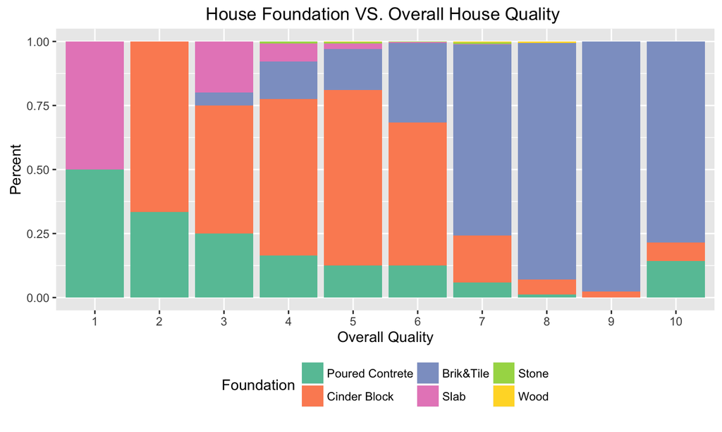

## Conclusion

- Popular house style changes with time
  - Some house style no longer popular and disappear in the market
- It is possible to get a deal in off peak house market season.
- Estimate house price from building structure and house location
- House built year and house overall quality relationship in future analysis

**Thank you!**